# Gráficos con ggplot2 (C): Tipos de gráficos

Programación y manejo de datos con R (Slides 06-C)

Pedro J. Pérez

pedro.j.perez@uv.es

## 8. Distintos tipos de gráficos

Mientras entendíamos el funcionamiento de ggplot2 nos centramos en un solo tipo de gráfico: los gráficos de puntos

Ahora veremos distintos tipos de gráficos: histogramas, gráficos de cajas, de barras, de líneas, scatter plots, etc… etc…

## Galerías con ejemplos

En estas slides presentaremos ejemplos de algunos de los gráficos más utilizados en el análisis de datos. Puedes ver listados más completos en:

- [[R-graph gallery]](https://www.r-graph-gallery.com/): Impresionante!!
- [[Top 50 ggplot2 Visualizations (With Full R Code)]](http://r-statistics.co/Top50-Ggplot2-Visualizations-MasterList-R-Code.html): de r-statistics.co, más básico pero muy didáctico
- [[Extensiones ggplot2]](https://exts.ggplot2.tidyverse.org/): Impresionante!!
- [[R-graph gallery - ggplot2 package]](http://r-graph-gallery.com/ggplot2-package.html): otra vez, impresionante!!

## ¿Qué gráfico uso?

Depende de **qué quieres mostrar** y de **qué tipo de variables** tienes:

| Qué quieres mostrar | Variables | Gráfico |  | geom |
| --- | --- | --- | --- | --- |
| La evolución en el tiempo | fecha + 1 continua | líneas |  | `geom_line()` |
| La relación entre dos variables | 2 continuas | puntos (scatter) |  | `geom_point()` |
| Cuántas observaciones hay de cada categoría | 1 categórica | barras |  | `geom_bar()` |
| Un valor (ya calculado) para cada categoría | 1 categórica (+ 1 numérica) | barras |  | `geom_col()` |
| La distribución de una variable | 1 continua | histograma, densidad |  | `geom_histogram()`, `geom_density()` |
| Comparar distribuciones entre grupos | 1 continua + 1 categórica | boxplot, violín, ridges |  | `geom_boxplot()`, `geom_violin()`, `ggridges` |

Evidentemente, **el tipo de gráfico se ha de elegir en función de la información que se quiere mostrar**. [[Aquí]](https://coolinfographics.com/dataviz-guides) puedes encontrar ayuda para elegir el tipo de gráfico. Por ejemplo:

[[From Data to Viz]](https://www.data-to-viz.com/), [[The Data Visualisation Catalogue]](https://datavizcatalogue.com/), [[The chart chooser]](https://extremepresentation.com/design/7-charts/), [[The Chart Chooser: Interactive Version]](http://labs.juiceanalytics.com/chartchooser/index.html), etc …

En las siguientes slides veremos un ejemplo de cada uno

## 8.1 Gráficos de líneas

Se utilizan sobre todo para mostrar la evolución de una variable en el tiempo (series temporales)

## Gráficos de líneas con geom_line()

```r
economics |>
```

```r
economics |>
ggplot(aes(date, unemploy)) +
```

```r
economics |>
ggplot(aes(date, unemploy)) +
geom_line() +
```

```r
economics |>
ggplot(aes(date, unemploy)) +
geom_line() +
geom_line(color = "steelblue", linewidth = 1) +
```

```r
economics |>
ggplot(aes(date, unemploy)) +
geom_line() +
geom_line(color = "steelblue", linewidth = 1) +
scale_x_date(date_breaks = "10 years", date_labels = "%Y") +
```

```r
economics |>
ggplot(aes(date, unemploy)) +
geom_line() +
geom_line(color = "steelblue", linewidth = 1) +
scale_x_date(date_breaks = "10 years", date_labels = "%Y") +
labs(x = NULL, y = "Desempleados (miles)",
     title = "Desempleo en EE.UU.")
```

```
#> # A tibble: 6 × 6
#>   date         pce    pop psavert uempmed unemploy
#>   <date>     <dbl>  <dbl>   <dbl>   <dbl>    <dbl>
#> 1 1967-07-01  507. 198712    12.6     4.5     2944
#> 2 1967-08-01  510. 198911    12.6     4.7     2945
#> 3 1967-09-01  516. 199113    11.9     4.6     2958
#> 4 1967-10-01  512. 199311    12.9     4.9     3143
#> 5 1967-11-01  517. 199498    12.8     4.7     3066
#> 6 1967-12-01  525. 199657    11.8     4.8     3018
```

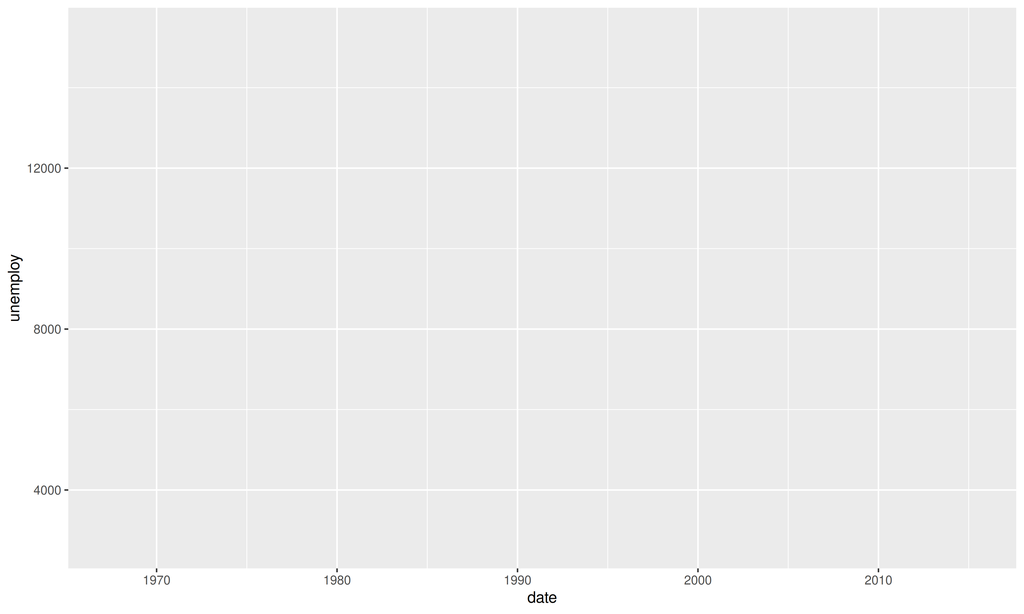

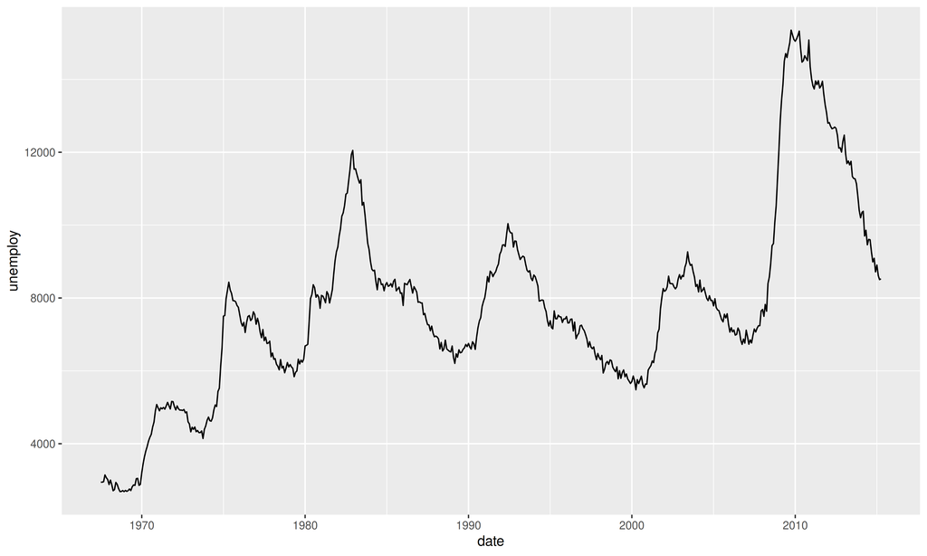

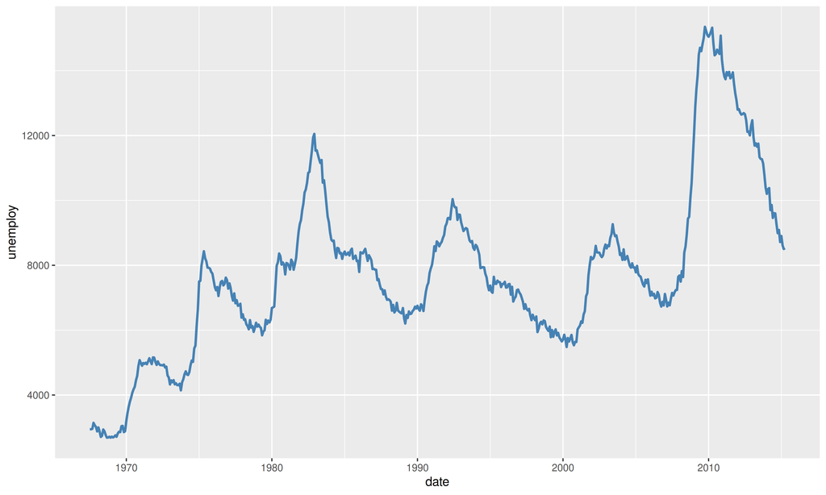

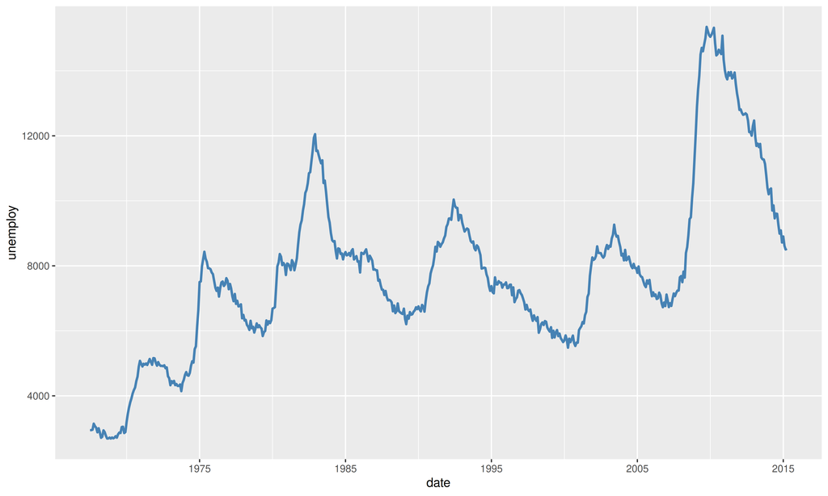

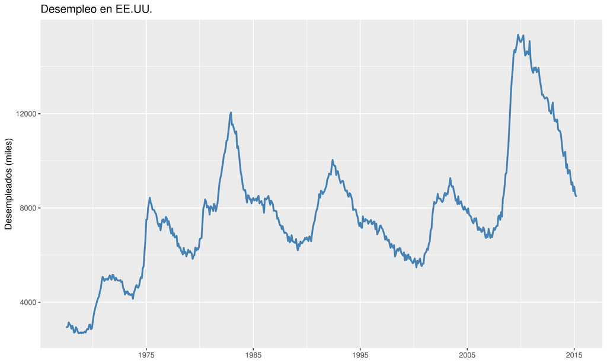

## Gráficos de líneas: varias series

- Si los datos están en formato *largo* (una columna con el nombre de la serie y otra con su valor), basta con mapear esa columna a `color`

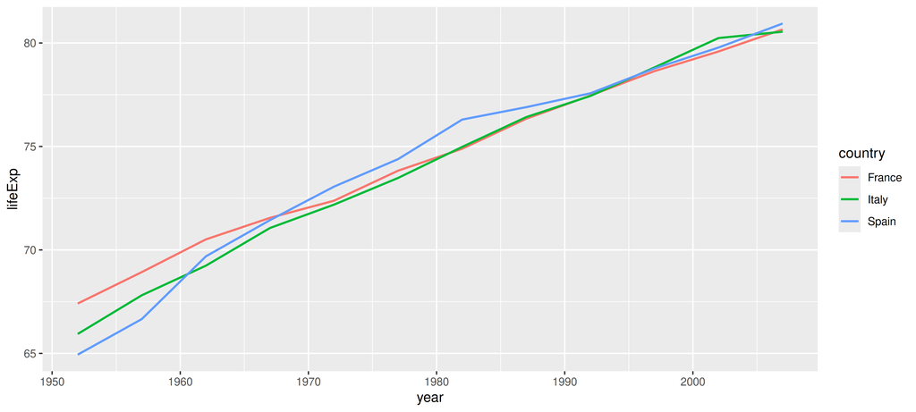

```r
gapminder::gapminder |>
  filter(country %in% c("Spain", "France", "Italy")) |>
  ggplot(aes(year, lifeExp, color = country)) +
  geom_line(linewidth = 0.8)
```

## Gráficos de líneas: ¿por qué no sale bien?

- Tarea
- Solución
- Tarea: queremos la esperanza de vida de España, Francia e Italia. ¿Por qué sale este gráfico tan raro?

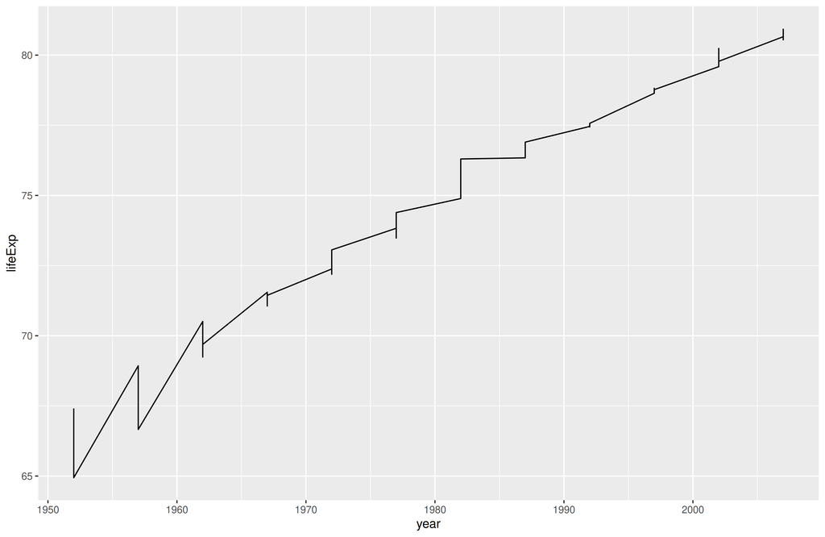

```r
df_gap <- gapminder::gapminder |>
  filter(country %in%
           c("Spain", "France", "Italy"))

ggplot(df_gap, aes(year, lifeExp)) +
  geom_line()
```

- `geom_line()` une los puntos en el orden del eje X, pero cada año hay 3 puntos (uno por país): por eso hace “zigzag”. Hay que decirle qué puntos van juntos, con `group` … o con `color`, que también agrupa

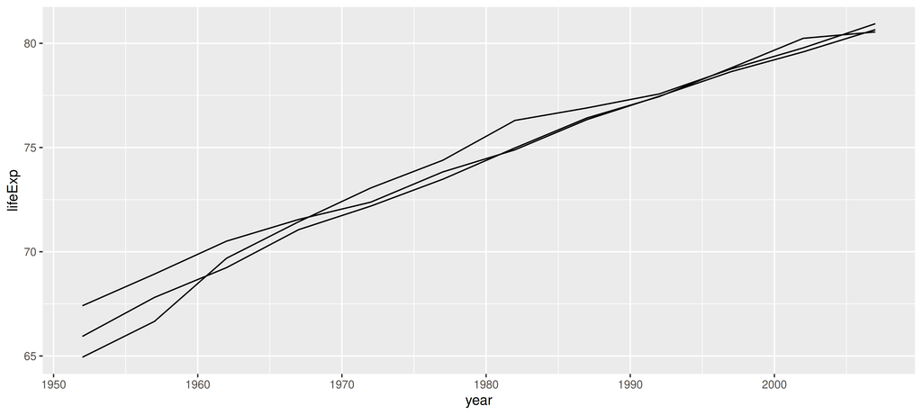

```r
ggplot(df_gap,
       aes(year, lifeExp, group = country)) +
  geom_line()
```

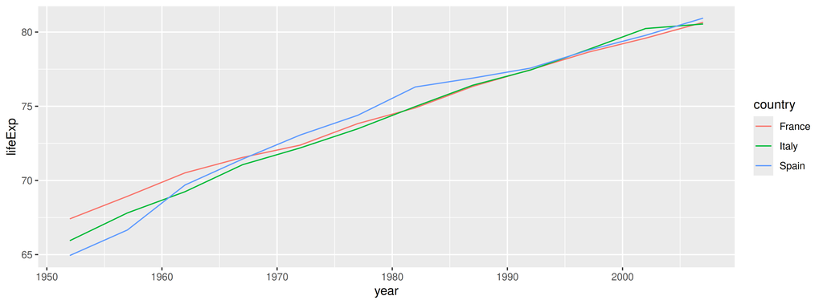

```r
ggplot(df_gap,
       aes(year, lifeExp, color = country)) +
  geom_line()
```

## 8.2 Gráficos x-y (scatter plots)

Muestran la relación entre dos variables continuas. Los hemos usado todo el tema, así que aquí veremos algunas cosas útiles: poner el nombre de los países, destacar uno, una recta de regresión y qué hacer cuando hay muchos datos

## Poner el nombre de los países

- Los datos: la renta y la esperanza de vida de los países europeos en 2007

```r
df_europa <- gapminder::gapminder |>
  filter(continent == "Europe", year == 2007)
```

- `geom_text()`
- `ggrepel`

```r
ggplot(df_europa, aes(gdpPercap, lifeExp)) +
  geom_point() +
  geom_text(aes(label = country))
```

- Los nombres se montan unos encima de otros …

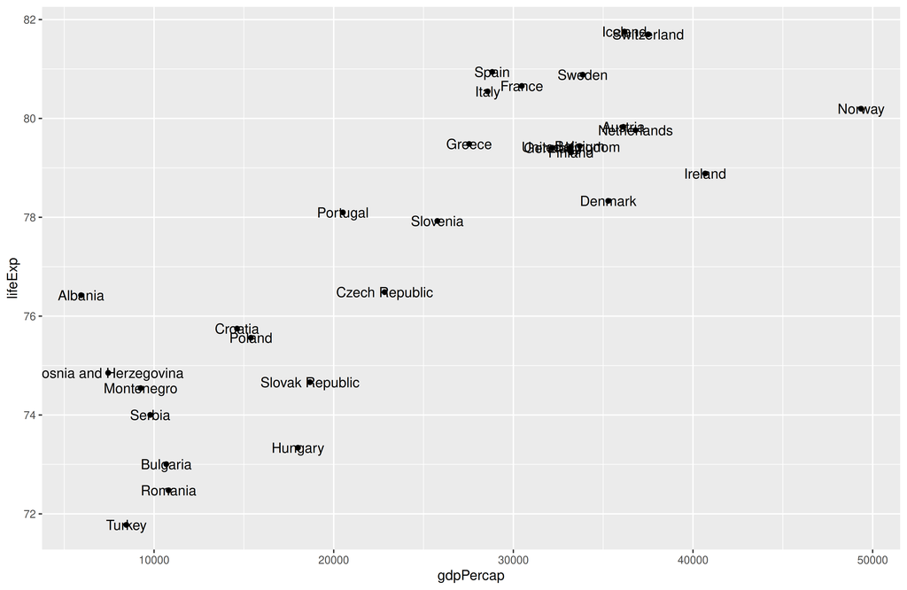

```r
ggplot(df_europa, aes(gdpPercap, lifeExp)) +
  geom_point() +
  ggrepel::geom_text_repel(aes(label = country),
                           size = 3)
```

- El paquete `ggrepel` los separa para que no se monten (y, si hace falta, pone una rayita hasta su punto)

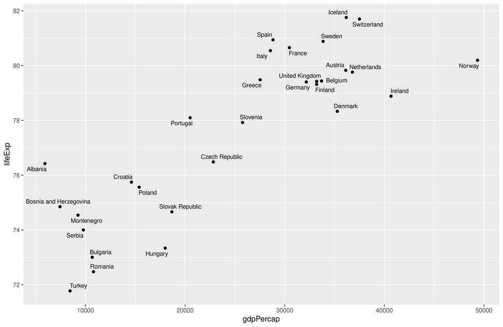

## Destacar un país y la recta de regresión

- Destacar un país
- La recta de regresión

```r
espana <- df_europa |> filter(country == "Spain")

ggplot(df_europa, aes(gdpPercap, lifeExp)) +
  geom_point(color = "grey60") +
  geom_point(data = espana, color = "firebrick",
             size = 3) +
  geom_text(data = espana, aes(label = country),
            color = "firebrick", vjust = -1)
```

- Como en el gráfico del paro de las slides B: el resto en gris, y en color solo lo que importa. Cada capa puede tener sus propios datos (`data = espana`)

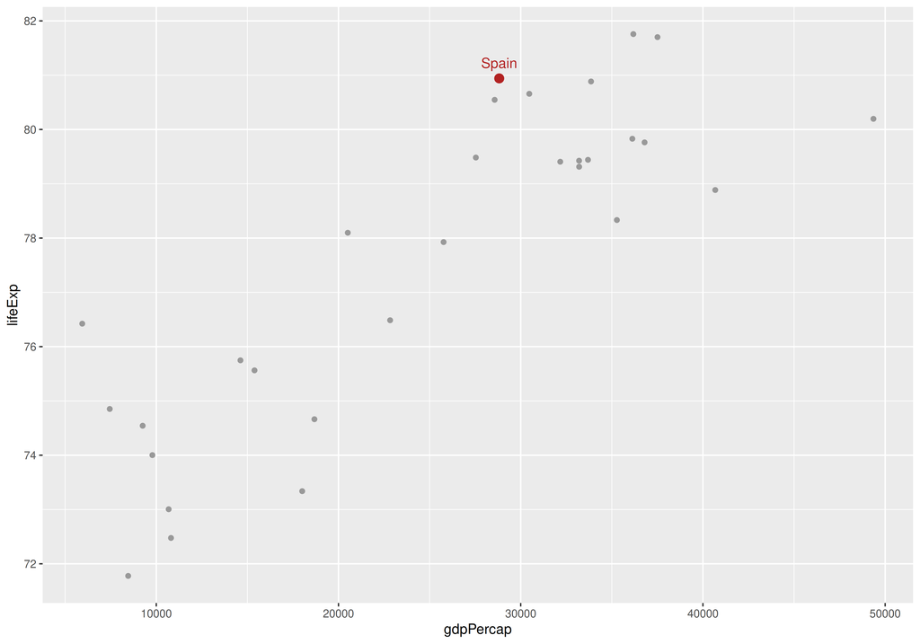

```r
ggplot(df_europa, aes(gdpPercap, lifeExp)) +
  geom_point() +
  geom_smooth(method = "lm")
```

- `geom_smooth()` dibuja una línea que resume la relación. Con `method = "lm"`, la recta de regresión
- La banda gris es el intervalo de confianza. Para quitarla: `se = FALSE`

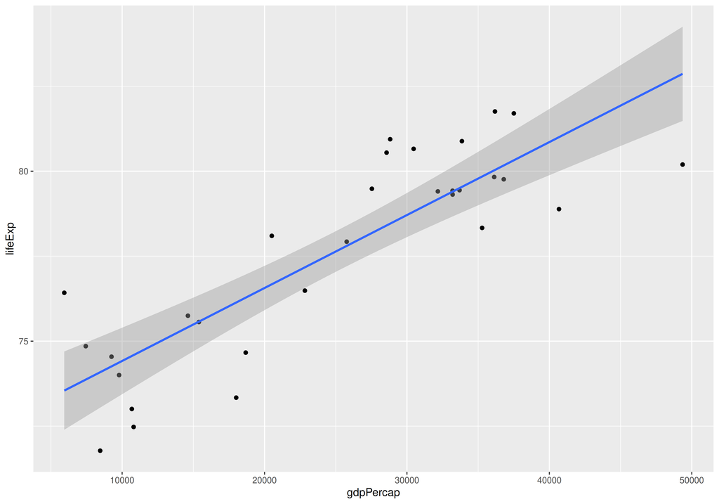

## Scatter plots: el problema del *overplotting*

- Con muchas observaciones (`diamonds` tiene casi 54.000) los puntos se tapan unos a otros y no vemos dónde hay más datos. Soluciones: **transparencia** (`alpha`) o **contar puntos por zonas** (`geom_bin2d()`)

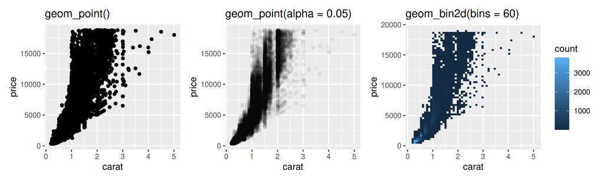

```r
ggplot(diamonds, aes(carat, price)) + geom_point()
ggplot(diamonds, aes(carat, price)) + geom_point(alpha = 0.05)
ggplot(diamonds, aes(carat, price)) + geom_bin2d(bins = 60)
```

## 8.3 Gráficos de barras y de columnas

Muestran cuántas observaciones hay de cada categoría (`geom_bar()`) o un valor ya calculado para cada categoría (`geom_col()`)

## Gráficos de barras con geom_bar()

```r
ggplot(mpg, aes(y = class)) +
```

```r
ggplot(mpg, aes(y = class)) +
geom_bar() +
```

```r
ggplot(mpg, aes(y = class)) +
geom_bar() +
geom_bar(fill = "steelblue")
```

- Para que las barras salgan en horizontal basta con poner la variable en el eje Y: `aes(y = class)`. Antes se hacía con `coord_flip()`, y lo verás en muchos ejemplos de internet
- Las barras salen en orden alfabético. Para ordenarlas hay que saber qué es un factor: lo vemos enseguida

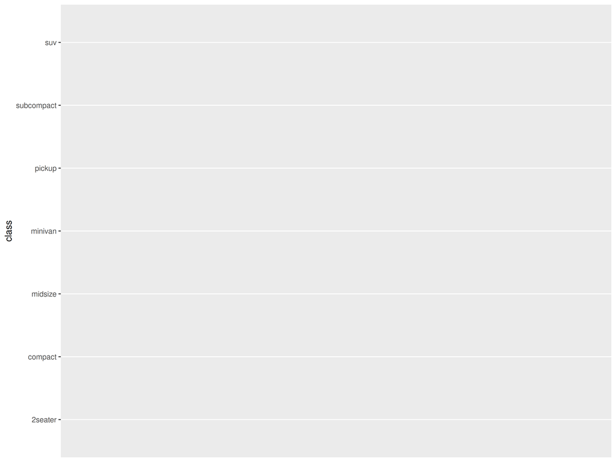

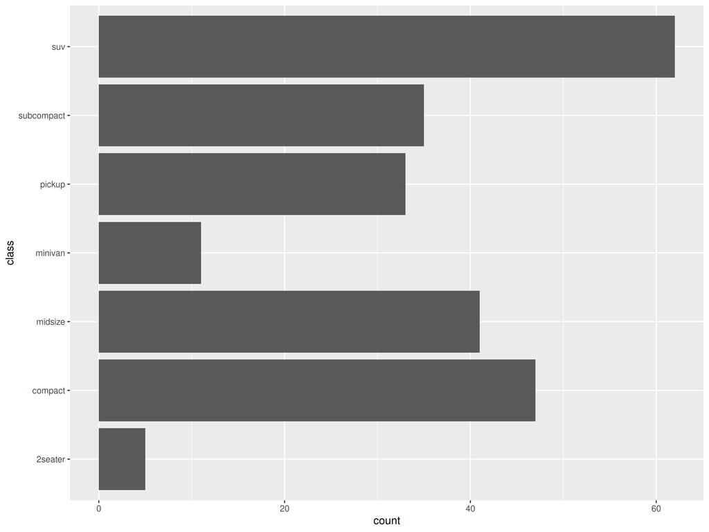

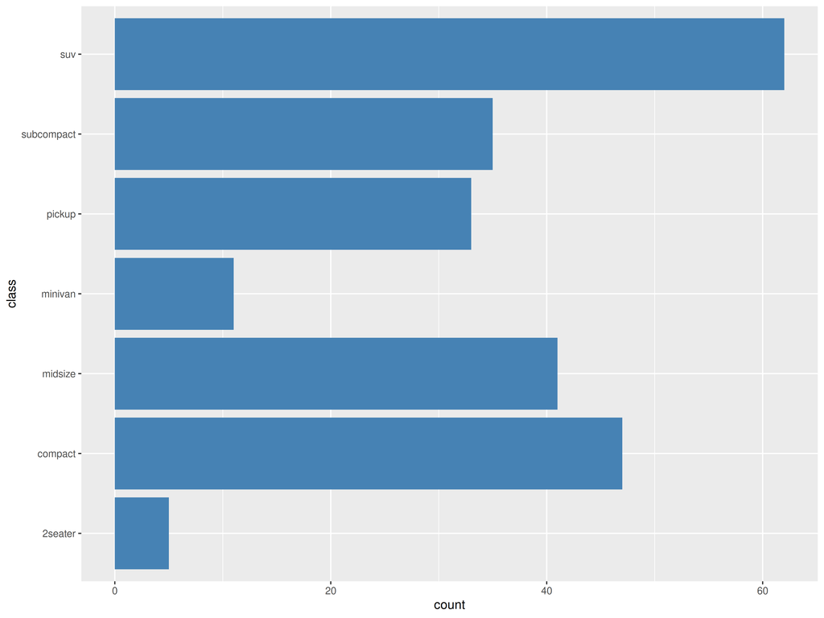

## `geom_bar()` vs `geom_col()` [ 🌟 ]

¿Cuántos pingüinos hay de cada especie? El **mismo gráfico** se puede hacer de dos formas:

**`geom_bar()`: R cuenta por ti**. Le das los datos originales (una fila por pingüino) y sólo `x`

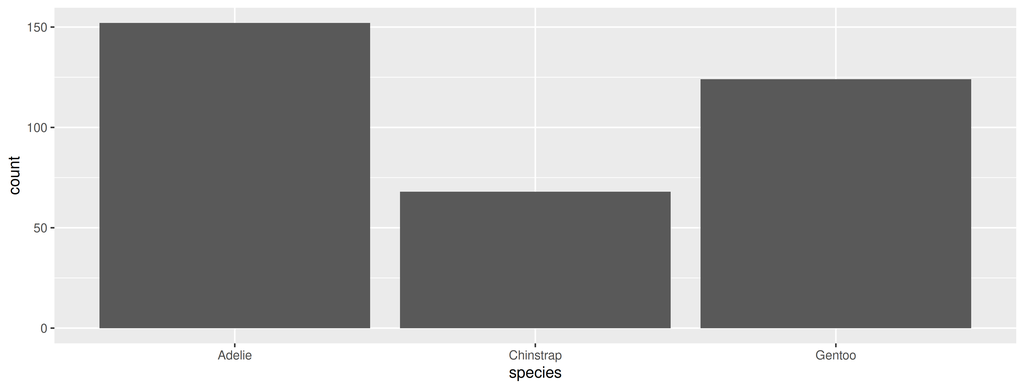

```r
ggplot(penguins, aes(x = species)) +
  geom_bar()
```

**`geom_col()`: tú le das la altura**. Primero cuentas (`count()` crea la columna `n`) y luego le das `x` e `y`

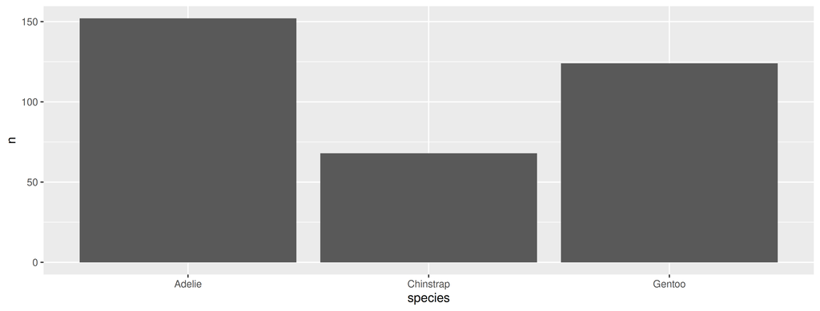

```r
penguins |> count(species) |>
  ggplot(aes(x = species, y = n)) +
  geom_col()
```

**Regla:**  
¿una fila por observación? → `geom_bar()`  
¿Ya tienes calculado el valor de cada barra (un recuento, una media, un %…)? → `geom_col()`

## Un paréntesis: factores

Para ordenar las cajas de un boxplot o las barras de un gráfico de barras, antes hay que saber qué es un factor

## ¿Qué es un factor?

- Un **factor** es la forma que tiene R de guardar variables categóricas: variables que solo pueden tomar unos valores concretos (especie, continente, nivel de estudios, …)  
  Además, un factor guarda cuáles son esas categorías (sus **levels**) y en qué orden van
- Veámoslo con unos datos inventados: los estudios y el sueldo de 8 personas

```r
encuesta <- tibble(
  estudios = c("Grado", "ESO", "Máster", "Grado", "Bachiller", "Grado", "ESO", "Bachiller"),
  sueldo   = c(1800, 1100, 2400, 2000, 1300, 1700, 1000, 1400))
```

```r
count(encuesta, estudios)
```

| estudios <chr> | n <int> |
| --- | --- |
| Bachiller | 2 |
| ESO | 2 |
| Grado | 3 |
| Máster | 1 |

- Ahora `estudios` es un string, y R lo ordena **alfabéticamente**
- Pero el orden natural es otro: ESO, Bachiller, Grado y Máster … ¿cómo se lo decimos a R?

## Crear un factor: `factor()`

- Con `factor()` le decimos a R cuáles son las categorías (los levels) y **en qué orden van**

```r
encuesta <- encuesta |>
  mutate(estudios = factor(estudios,
    levels = c("ESO", "Bachiller", "Grado", "Máster")))

levels(encuesta$estudios)
```

```
#> [1] "ESO"       "Bachiller" "Grado"     "Máster"
```

**1**

las categorías, en el orden que queremos

**2**

`levels()` nos dice cuáles son las categorías y en qué orden van

```r
count(encuesta, estudios)
```

| estudios <fct> | n <int> |
| --- | --- |
| ESO | 2 |
| Bachiller | 2 |
| Grado | 3 |
| Máster | 1 |

- Ahora `count()` respeta nuestro orden. Y fíjate en el tipo de la columna: `<fct>`

## algunos detalles sobre los factores

- Si no le damos los levels, `factor()` los pone en orden alfabético

```r
factor(c("Grado", "ESO", "Máster"))
```

```
#> [1] Grado  ESO    Máster
#> Levels: ESO Grado Máster
```

- Un valor que no esté entre los levels se convierte en `NA` … **¡sin avisar!**

```r
factor(c("Grado", "Doctorado"), levels = c("ESO", "Bachiller", "Grado", "Máster"))
```

```
#> [1] Grado <NA>
#> Levels: ESO Bachiller Grado Máster
```

- Muchas veces los factores ya vienen hechos: por ejemplo, `Species` en `iris`. Y para volver a tener un string: `as.character()`

```r
class(iris$Species)
```

```
#> [1] "factor"
```

## a veces necesitamos cambiar el orden de los levels

- Las funciones del paquete forcats (se carga con el tidyverse) empiezan todas por `fct_`

`fct_relevel()`: a mano

```r
levels(fct_relevel(encuesta$estudios, "Máster"))
```

```
#> [1] "Máster"    "ESO"       "Bachiller" "Grado"
```

`fct_infreq()`: por frecuencia

```r
levels(fct_infreq(encuesta$estudios))
```

```
#> [1] "Grado"     "ESO"       "Bachiller" "Máster"
```

`fct_rev()`: al revés

```r
levels(fct_rev(encuesta$estudios))
```

```
#> [1] "Máster"    "Grado"     "Bachiller" "ESO"
```

`fct_reorder()`: según otra variable

```r
levels(fct_reorder(encuesta$estudios,
                   encuesta$sueldo, .desc = TRUE))
```

```
#> [1] "Máster"    "Grado"     "Bachiller" "ESO"
```

- `fct_reorder()` ordena según la mediana del sueldo de cada categoría. `.desc = TRUE`: de mayor a menor

Cambiar el orden de los levels **no cambia los datos**: cambia cómo se ordenan las tablas y, sobre todo, los gráficos

## Cambiar las categorías

`fct_recode()`: cambiar el nombre (`"nuevo" = "viejo"`)

```r
encuesta |>
  mutate(estudios = fct_recode(estudios,
                     "Secundaria" = "ESO")) |>
  count(estudios)
```

| estudios <fct> | n <int> |
| --- | --- |
| Secundaria | 2 |
| Bachiller | 2 |
| Grado | 3 |
| Máster | 1 |

`fct_collapse()`: juntar varias categorías en una

```r
encuesta |>
  mutate(estudios = fct_collapse(estudios,
    "Universidad" = c("Grado", "Máster"))) |>
  count(estudios)
```

| estudios <fct> | n <int> |
| --- | --- |
| ESO | 2 |
| Bachiller | 2 |
| Universidad | 4 |

- Y si hay muchas categorías, `fct_lump_n(estudios, n = 2)` se queda con las 2 más frecuentes y junta las demás en `"Other"`

## Los factores deciden el orden de las categorías

- ggplot2 dibuja las categorías **en el orden de los levels**. Y si la variable es un string, en orden alfabético

```r
levels(iris$Species)
```

```
#> [1] "setosa"     "versicolor" "virginica"
```

```r
iris |>
  mutate(Species = fct_relevel(Species,
                               "virginica")) |>
  ggplot(aes(Species, Sepal.Width)) +
  geom_boxplot()
```

**1**

`fct_relevel()` pone `virginica` la primera; el resto se queda como estaba

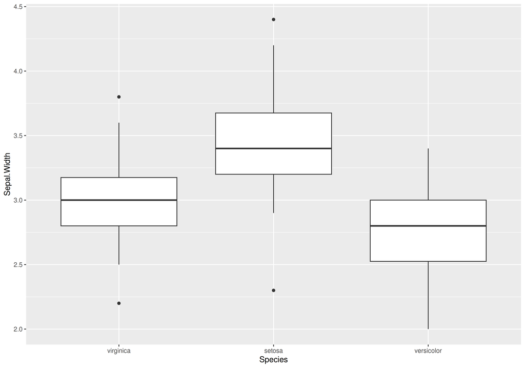

## Reordenar las categorías de un gráfico

- Para cambiar el orden de un gráfico no tocamos el gráfico: cambiamos el orden de los levels. Las funciones de forcats (todas empiezan por `fct_`):

| Para ordenar las categorías … | usamos … |
| --- | --- |
| según otra variable (por defecto, su mediana) | `fct_reorder(Species, Sepal.Width)` |
| según otra variable (según la media) | `fct_reorder(Species, Sepal.Width, .fun = mean)` |
| por frecuencia, de la más frecuente a la menos | `fct_infreq(class)` |
| a mano | `fct_relevel(Species, "virginica")` |
| al revés | `fct_rev(class)` |

- Se puede hacer **dentro de `aes()`**: `aes(fct_reorder(Species, Sepal.Width), Sepal.Width)`. Es rápido, pero el nombre del eje es toda la expresión, así que lo quitamos con `labs(x = NULL)`
- … o **antes, con `mutate()`**, como en la slide anterior: el eje conserva el nombre de la variable
- Ojo: en las barras horizontales la primera categoría sale abajo. Por eso a veces hace falta `fct_rev()`

## Ordenar las barras con `geom_bar()`

- `fct_infreq()` ordena las categorías por frecuencia y `fct_rev()` les da la vuelta (en las barras horizontales la primera categoría sale abajo). Como el nombre del eje sería toda esa expresión, lo quitamos con `labs(y = NULL)`

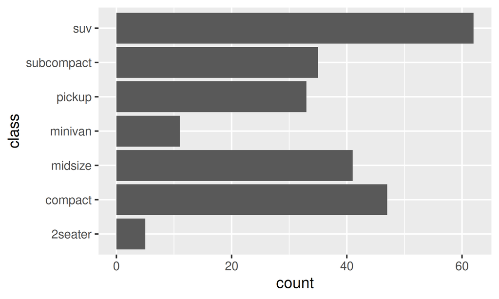

```r
ggplot(mpg, aes(y = class)) +
  geom_bar()
```

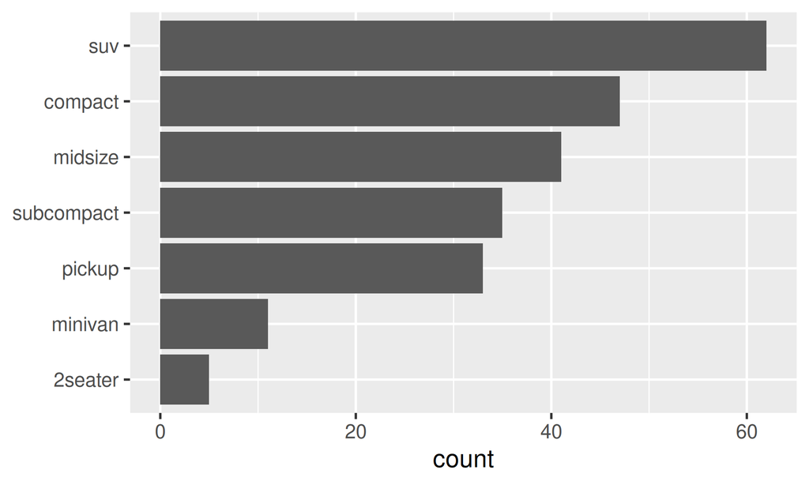

```r
ggplot(mpg, aes(y = fct_rev(fct_infreq(class)))) +
  geom_bar() + labs(y = NULL)
```

## Ordenar las barras con `geom_col()`

- Con `geom_bar()` ordenábamos por frecuencia con `fct_infreq()`. Con `geom_col()` el orden lo marca otra variable, la altura de cada barra: para eso está `fct_reorder()`

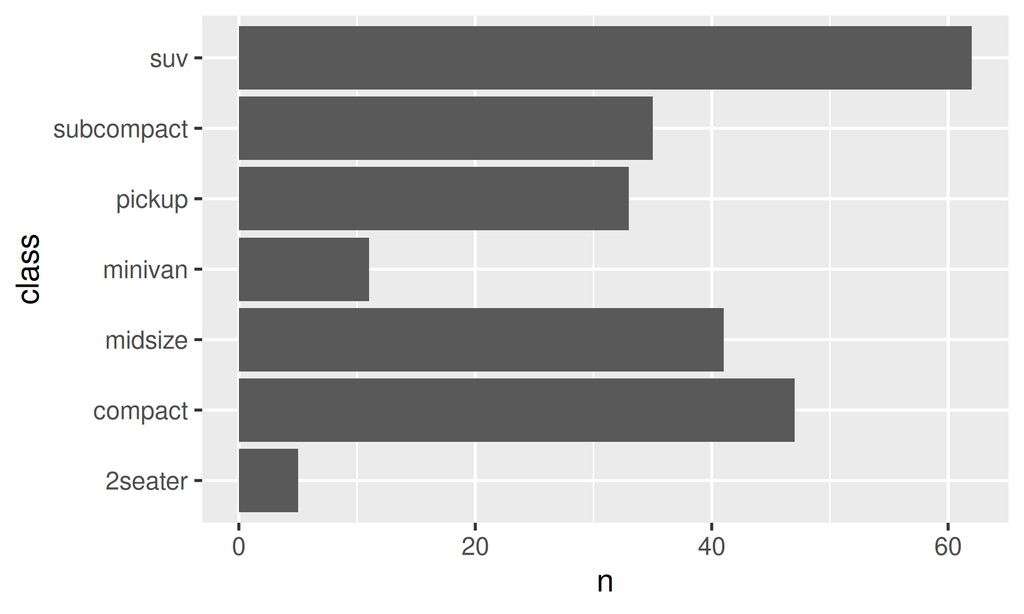

```r
mpg |> count(class) |>
  ggplot(aes(n, class)) +
  geom_col()
```

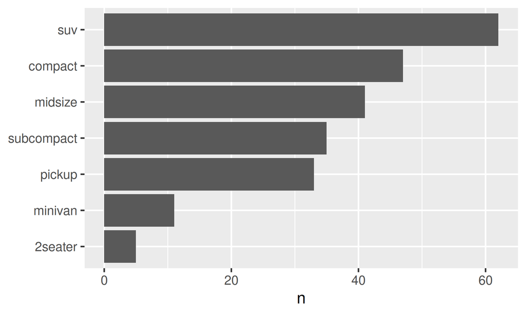

```r
mpg |> count(class) |>
  ggplot(aes(n, fct_reorder(class, n))) +
  geom_col() + labs(y = NULL)
```

- Ordenadas se leen mucho mejor: de un vistazo ves cuál es la mayor y cuál la menor

## 8.4 Histogramas

Se utilizan para mostrar la distribución de UNA variable continua, por ejemplo la longitud del sépalo (Sepal.Length)

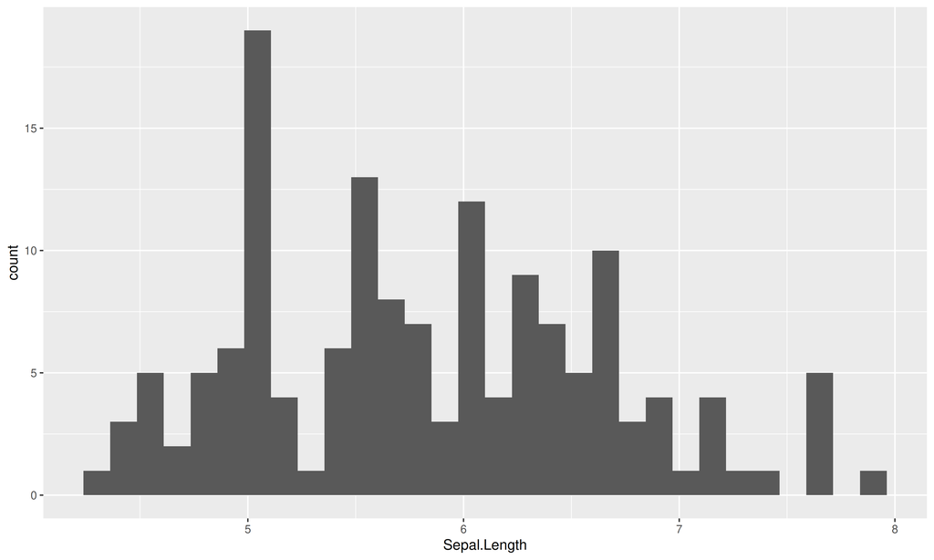

## Histogramas con geom_histogram()

```r
ggplot(iris, aes(Sepal.Length)) +
```

```r
ggplot(iris, aes(Sepal.Length)) +
geom_histogram(bins = 60) + labs(title = "60 intervalos") +
```

```r
ggplot(iris, aes(Sepal.Length)) +
geom_histogram(bins = 60) + labs(title = "60 intervalos") +
geom_histogram(bins = 40) + labs(title = "40 intervalos") +
```

```r
ggplot(iris, aes(Sepal.Length)) +
geom_histogram(bins = 60) + labs(title = "60 intervalos") +
geom_histogram(bins = 40) + labs(title = "40 intervalos") +
geom_histogram(binwidth = 0.5) + labs(title = "binwidth = 0.5") +
```

```r
ggplot(iris, aes(Sepal.Length)) +
geom_histogram(bins = 60) + labs(title = "60 intervalos") +
geom_histogram(bins = 40) + labs(title = "40 intervalos") +
geom_histogram(binwidth = 0.5) + labs(title = "binwidth = 0.5") +
geom_histogram(binwidth = 0.5, color = "black", fill = "tomato") +
```

```r
ggplot(iris, aes(Sepal.Length)) +
geom_histogram(bins = 60) + labs(title = "60 intervalos") +
geom_histogram(bins = 40) + labs(title = "40 intervalos") +
geom_histogram(binwidth = 0.5) + labs(title = "binwidth = 0.5") +
geom_histogram(binwidth = 0.5, color = "black", fill = "tomato") +
geom_histogram(binwidth = 0.5, aes(fill = Species), color = "black") +
```

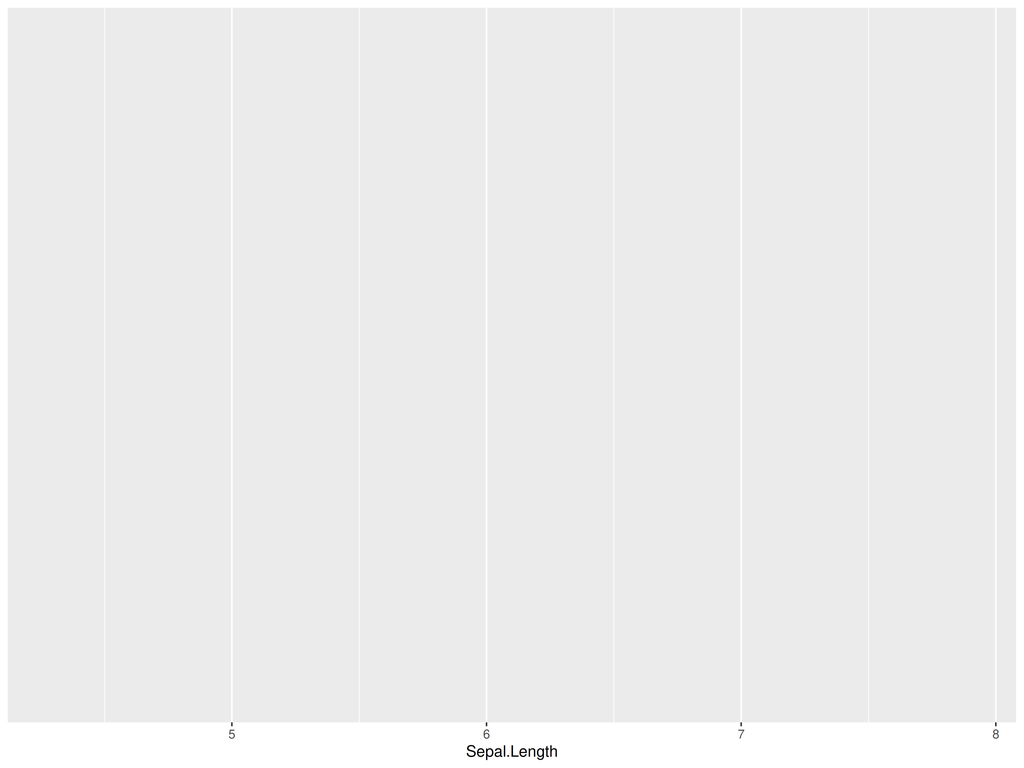

```r
ggplot(iris, aes(Sepal.Length)) +
geom_histogram(bins = 60) + labs(title = "60 intervalos") +
geom_histogram(bins = 40) + labs(title = "40 intervalos") +
geom_histogram(binwidth = 0.5) + labs(title = "binwidth = 0.5") +
geom_histogram(binwidth = 0.5, color = "black", fill = "tomato") +
geom_histogram(binwidth = 0.5, aes(fill = Species), color = "black") +
facet_grid(cols = vars(Species))
```

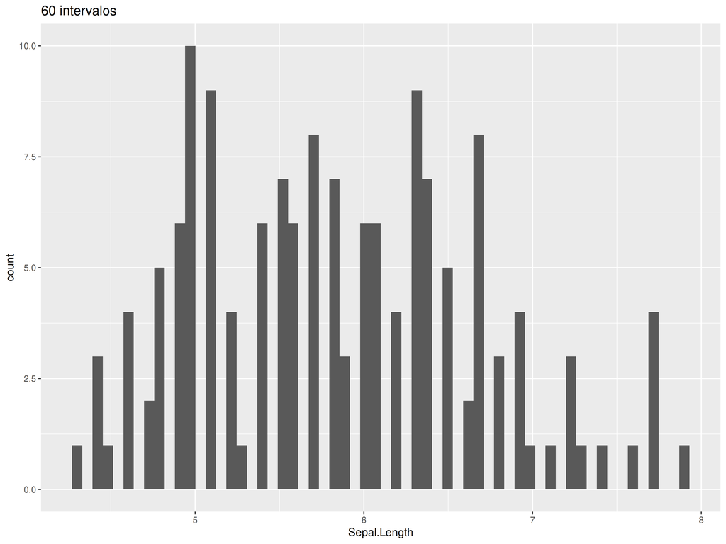

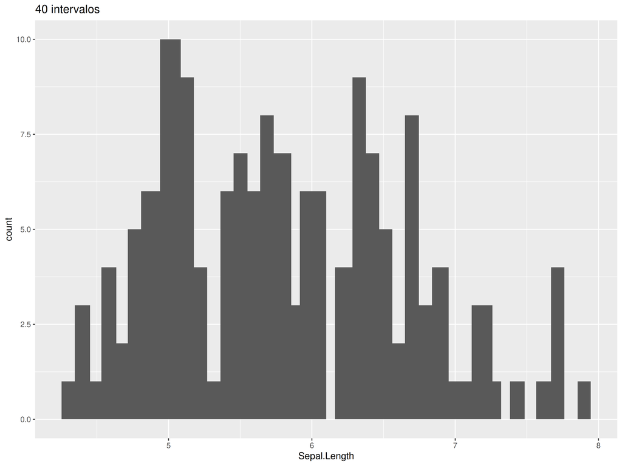

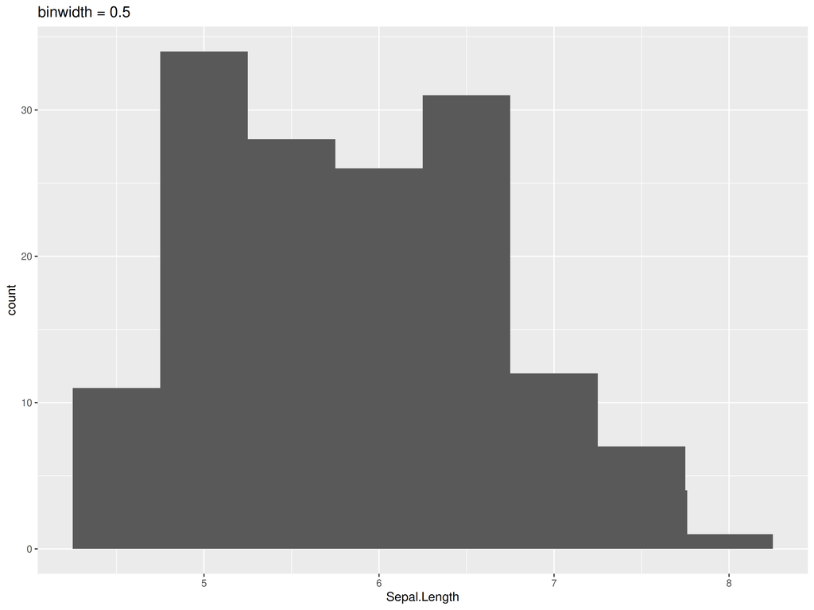

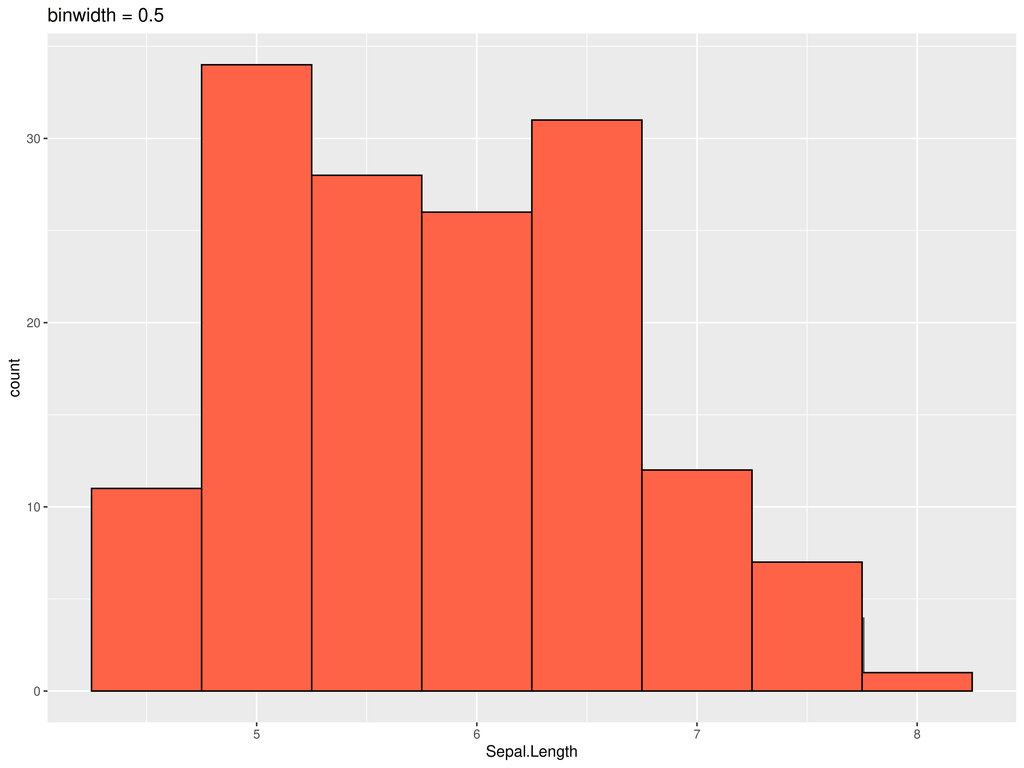

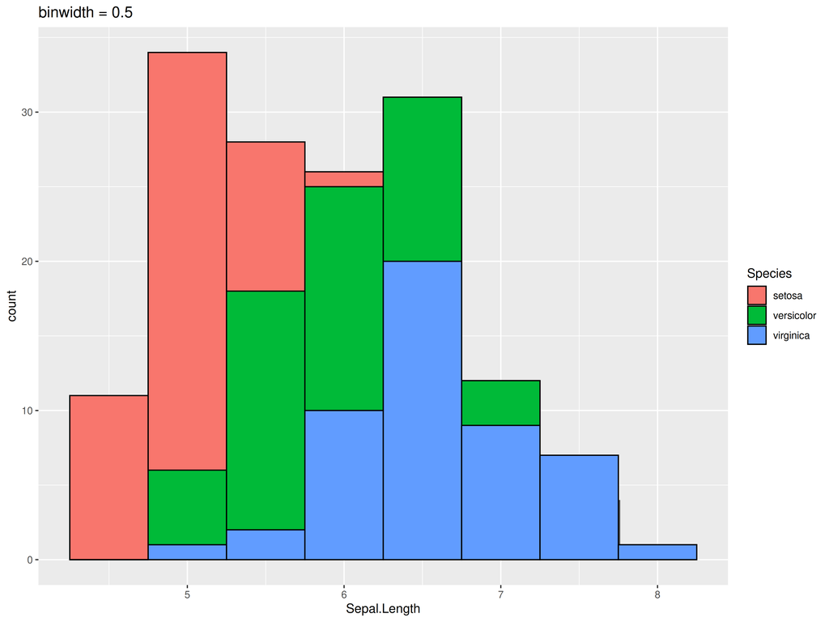

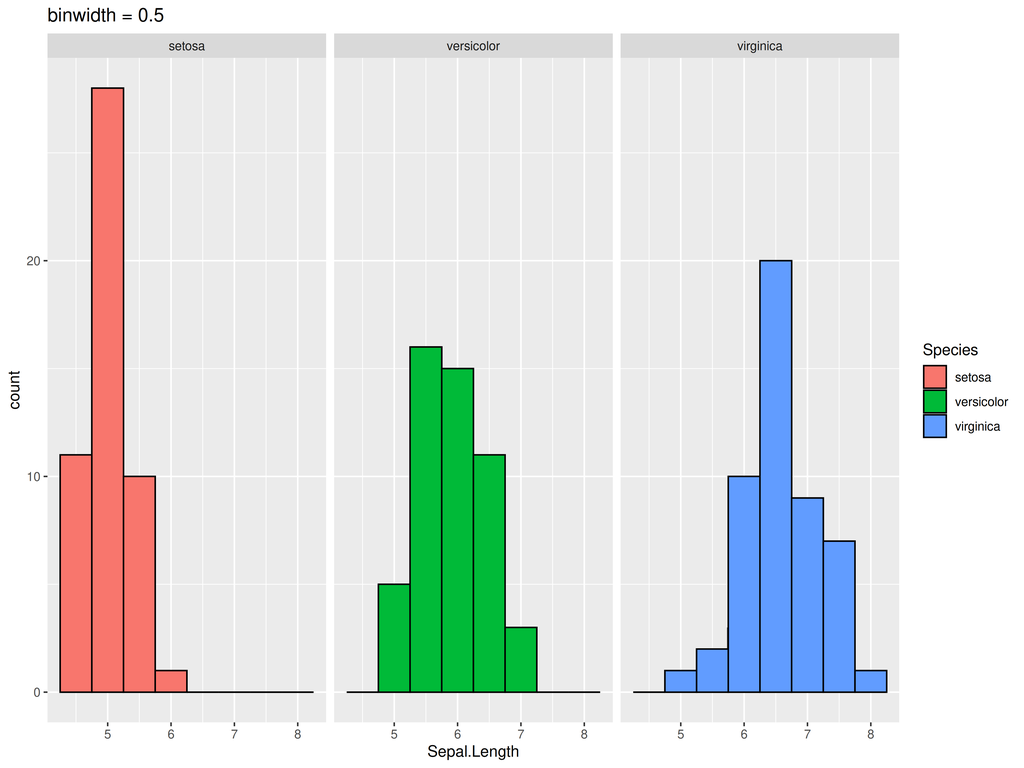

Con `bins` eliges el número de intervalos; con `binwidth`, su anchura. **¿Por qué elegir `bins` o `binwidth`?** Si no lo hacemos, ggplot2 usa 30 intervalos y nos avisa: *`stat_bin()` using `bins = 30`. Pick better value with `binwidth`*. El número de intervalos cambia mucho la forma del histograma: hay que probar varios.